# Handout- Probability

Jacob Thoma

## On your own

### Comparing Kobe Bryant to the Independent Shooter

Using `calc_streak`, compute the streak lengths of `sim_basket`.

1. Describe the distribution of streak lengths. What is the typical streak length for this simulated independent shooter with a 45% shooting percentage? How long is the player’s longest streak of baskets in 133 shots?

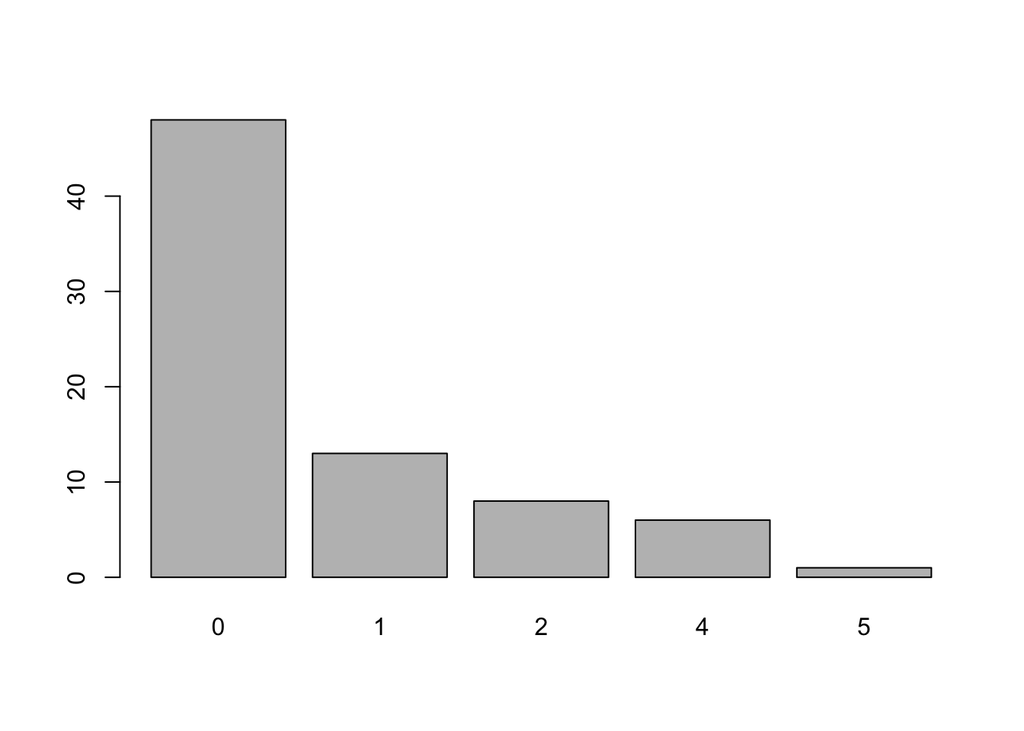

```r
# Load Data & calc_streak func
download.file("http://www.openintro.org/stat/data/kobe.RData", destfile = "kobe.RData")
load("kobe.RData")

# Prepare data
outcomes <- c("H", "M")
sim_basket <- sample(outcomes, size = 133, replace = TRUE)

# Calculate and examine simulated player streak
sim_streak <- calc_streak(sim_basket)
barplot(table(sim_streak))
```

2. If you were to run the simulation of the independent shooter a second time, how would you expect its streak distribution to compare to the distribution from the question above? Exactly the same? Somewhat similar? Totally different? Explain your reasoning.

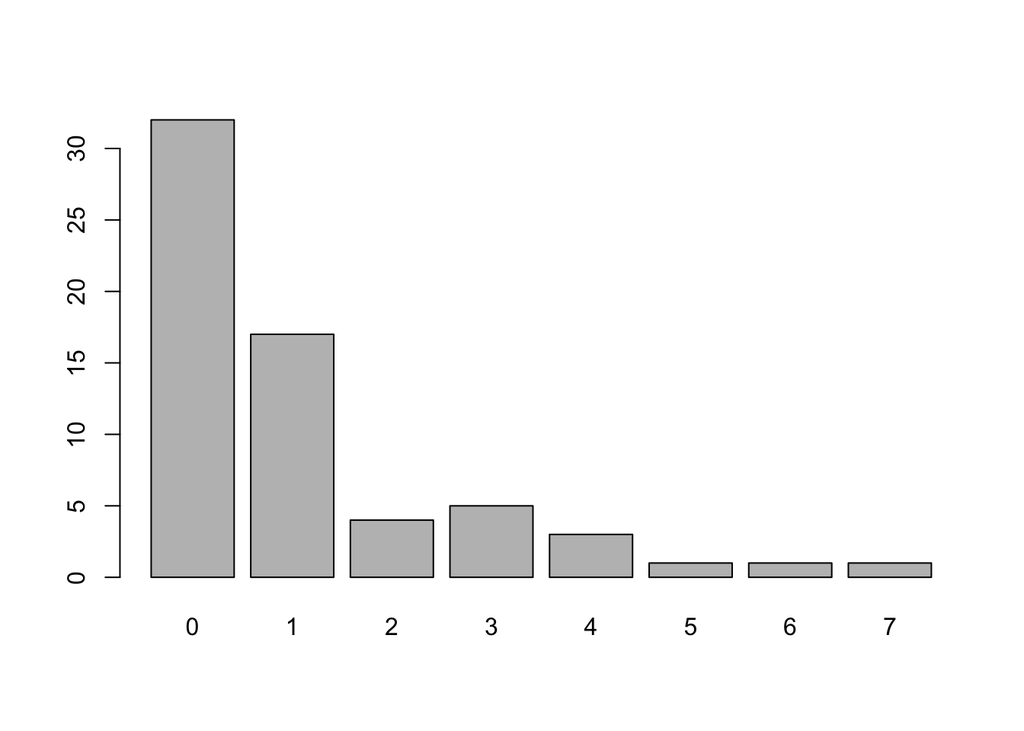

```r
# Load Data & calc_streak func
download.file("http://www.openintro.org/stat/data/kobe.RData", destfile = "kobe.RData")
load("kobe.RData")

# Prepare data
outcomes <- c("H", "M")
sim_basket <- sample(outcomes, size = 133, replace = TRUE)

# Calculate and examine simulated player streak
sim_streak <- calc_streak(sim_basket)
barplot(table(sim_streak))
```

3. How does Kobe Bryant’s distribution of streak lengths compare to the distribution of streak lengths for the simulated shooter? Using this comparison, do you have evidence that the hot hand model fits Kobe’s shooting patterns? Explain.

   *Answer:* Although I am dismayed to say it the distribution of Kobe’s shots and the simulated player’s shots are very similar, pointing away from from the hot hand model for Kobe’s shooting pattern. If Kobe’s shot results were a result of a hot hands model we would expect to see more actual streak lengths that were greater than 0. Additionaly we would likely expect the maxiumum streak length to be longer than that of the simulated player.

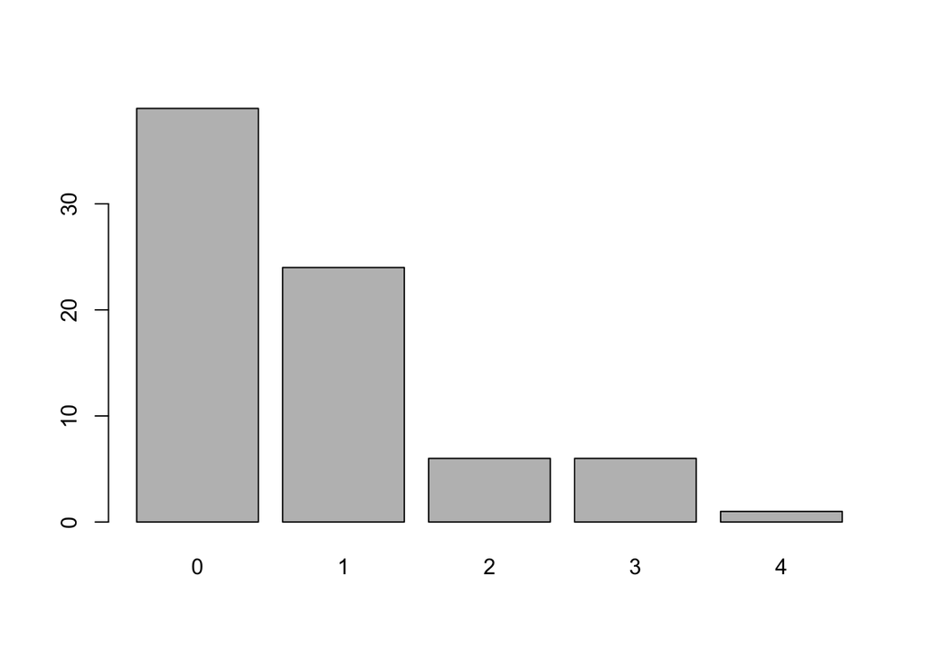

```r
# Load Data & calc_streak func
download.file("http://www.openintro.org/stat/data/kobe.RData", destfile = "kobe.RData")
load("kobe.RData")

# Calculate and plot any Kobe streaks
kobe_streak <- calc_streak(kobe$basket)
barplot(table(kobe_streak))
```

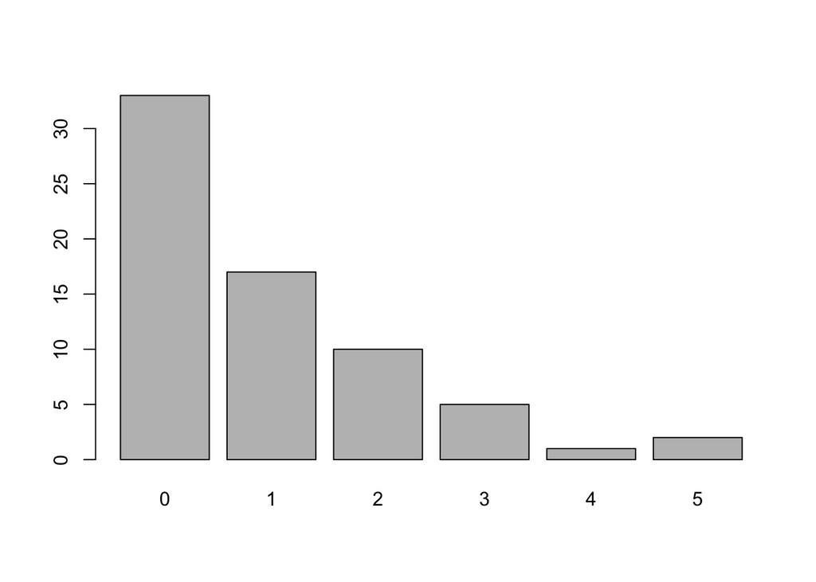

```r
# Prepare sim data data
outcomes <- c("H", "M")
sim_basket <- sample(outcomes, size = 133, replace = TRUE)

# Calculate and examine simulated player streak
sim_streak <- calc_streak(sim_basket)
barplot(table(sim_streak))
```

This is a product of OpenIntro that is released under a [Creative Commons Attribution-ShareAlike 3.0 Unported](http://creativecommons.org/licenses/by-sa/3.0). This lab was adapted for OpenIntro by Andrew Bray and Mine Çetinkaya-Rundel from a lab written by Mark Hansen of UCLA Statistics.